# CDC Fall Narrative Submission

Salish Research Group

2023-10-05

# **Combining Expert Consensus and AI to Reduce Fall Risk**

# *A hybrid qualitative-analytic approach*

*Salish Research Group*

*Brian K Erly, MD MPH*

*Steven J Erly, PhD MPH*

salishresearchgroup.com

salishresearchgroup@gmail.com

## Introduction

Falls are one of the leading causes of injury and mortality in elderly populations. Among people age 75 and older, an estimated 1/3 of individuals will fall within a given year and 1/4 individuals will suffer serious injury in a fall. Although there has been significant work in identifying risk factors for falls, there is a lack of approachable frameworks for primary prevention of falls.

The purpose of this project was to demonstrate the use of machine learning and natural language processing (NLP) to supplement qualitative coding and abstraction of medical record narratives and develop a risk reduction tool for primary prevention of falls. Our project uses a unique combination of methodologies to develop our model: qualitative analysis, saturation modelling, and NLP.

By basing our analysis on qualitative methods, we are able to leverage subject matter expertise and human judgement. This grounds our results in clinical practice and ensures that we create a tool that is acceptable and interpretable to medical providers. However, qualitative methods are labor intensive and not suitable for research on datasets with thousands of records. By applying NLP and random forest imputation, we are able to extend qualitative research to big data applications and develop estimates that are precise and applicable to uncommon subpopulations.

Formally, our project goals are:

1. Use machine learning to extend human coding of qualitative research themes to novel data
2. Develop a risk reduction tool for falls for use in primary prevention

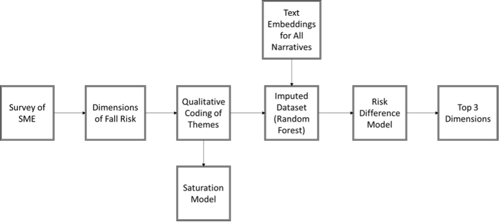

Methods Overview

```r
#Set Up Environment

## Load packages
library(tidyverse)
library(ggthemes)
library(lubridate)
library(gridExtra)
library(MASS)
library(episensr)
library(arrow)
library(missForest)
```

## Part 1: Expert Panel

### Methods

In order to ascertain key factors and domains resulting in medically significant falls in persons over 65, we convened a panel of physician experts to participate in a two-step process, involving both a structured interview and a follow up questionnaire.

Participants were solicited from across a range of specialties, including emergency/urgent care, medical, and surgical roles. Participants were asked to commit to a 15 minute interview and 10 minute follow up questionnaire. All participants who completed both the interview and questionnaire received a small gift (value <$50).

The initial interview commenced with a review of the project and goals. Next, each panel member was asked about their practice context and the percentage of patients who they see for fall-related complaints. This was followed up with a series of questions designed to elicit causes of severe falls in persons over 65, including causes which make a fall more likely and causes which might cause a fall to be more medically consequential.

Each panel member then received a follow up questionnaire as a Google form. This follow up questionnaire was centered around identifying the most important factors leading to falls.

For each of 29 injury patterns, participants were asked to select the degree to which each was associated with frailty in elderly fall patients. Each injury pattern was ranked from 1 (“Not associated with frailty”) to 4 (“Pathognomonic for frailty”).

Next, each participant was asked to rank 10 factors in order of their association with risk of serious injury in patients over 65 years old. Participants were instructed to rank all factors in order, with no ties.

### Results

Seven physicians were contacted to participate in the panel, of whom 5 elected to participate (71.4%). All participants who agreed to participate in the initial panel completed both the structured interview and follow up questionnaire. The panel was composed of one physician each from the following specialties; emergency medicine, otolaryngology, neurosurgery, orthopedic surgery, and internal medicine. All participants were board-eligible or board-certified in their specialty`.

All respondents responded with a range estimate of their practice time treating patients due to medical consequences of falls, with a midpoint median of 7.5% (range 2.5-27.5%).

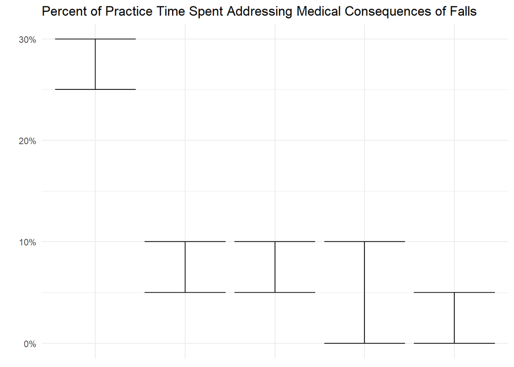

```r
# Load practice time data
practice_time <- read_csv("Data/Practice Time.csv")

# Output plot
ggplot(data = practice_time,aes(x=reorder(respondant,-mid))) +
  geom_errorbar(aes(ymin= low/100,ymax = high/100))+
  theme_minimal()+
  ylab("")+
  xlab("")+
  theme(
    axis.title.x = element_blank(),
    axis.text.x = element_blank(),
  )+
  scale_y_continuous(labels = scales::percent)+
  labs(title = "Percent of Practice Time Spent Addressing Medical Consequences of Falls")
```

Panel members identified eight classes of medication associated with falls, as well as nine underlying medical conditions which might lead to more severe falls in an elderly person (Table 1).

Table 1: Medication classes identified as associated with falls during unstructured clinician panel interviews.

| **Medication / Therapeutic Class** | **Mentions** | **Percent** |
| --- | --- | --- |
| Opioids / Pain Medications | 5 | 100% |
| Polypharmacy / Drug Interaction | 3 | 60% |
| Alcohol | 2 | 40% |
| Antihypertensives | 2 | 40% |
| Anticholinergics | 2 | 40% |
| Anxiolytics | 2 | 40% |
| Antidiabetic | 1 | 20% |
| Blood thinners | 1 | 20% |

| **Underlying Medical Conditions** | **Mentions** | **Percent** |
| --- | --- | --- |
| Deconditioning | 3 | 60% |
| Dementia | 2 | 40% |
| Gait disturbance | 2 | 40% |
| Neuropathy | 2 | 40% |
| Balance disorder | 1 | 20% |
| Hypotension or Syncope | 1 | 20% |
| Visual Changes | 1 | 20% |
| Arthritis | 1 | 20% |
| Renal disease | 1 | 20% |

Panelists ranked fall energy as the most important factor associated with the likelihood of a fall related injury (median ranking 1/10), followed by fragility (median ranking 2/10). Intoxication, inappropriate medication or overmedication, medical conditions affecting stability/balance, and cardiac and neurovascular conditions affecting consciousness were all tied for third-place (median ranking 4/10).

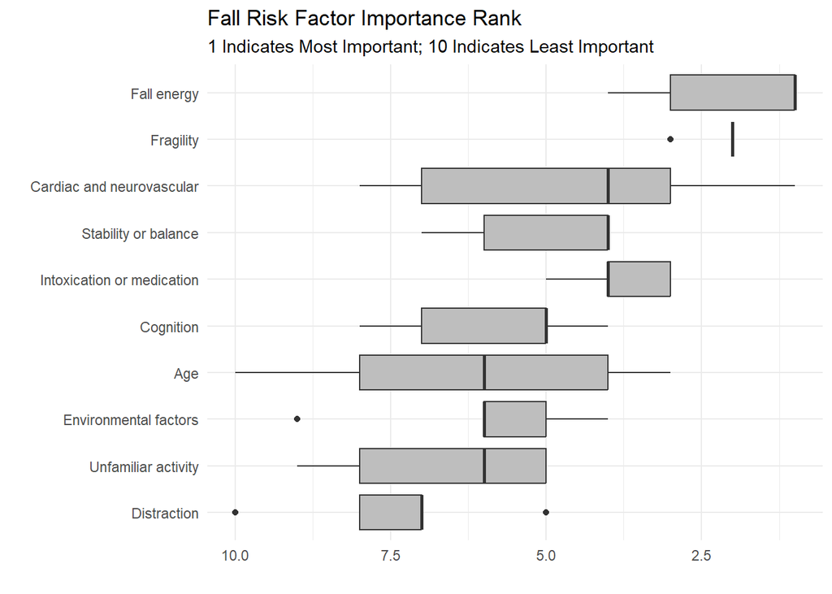

```r
# Load injury pattern data
fall_factor_import <- read_csv("Data/factor interview data.csv")

fall_factors <- fall_factor_import %>%
  # remove brackets
  mutate(Factor = stringi::stri_replace_all_fixed(Factor,"[","")) %>%
  mutate(Factor = stringi::stri_replace_all_fixed(Factor,"]","")) %>%

  arrange(desc(Median)) %>%

  mutate(Factor = factor(Factor,
                         levels = unique(Factor))) %>%
  dplyr::select(-Median,-Mean) %>%
  # # convert to long format
  pivot_longer(-Factor,names_to = "respondent",values_to = "ranking")


fall_factors %>%
  ggplot(aes(x=Factor,y=ranking))+
  geom_boxplot(fill="grey")+
  coord_flip()+
  xlab("")+
  ylab("") +
  scale_y_reverse()+
  labs(title = "Fall Risk Factor Importance Rank",
       subtitle = "1 Indicates Most Important; 10 Indicates Least Important")+
  theme_minimal()
```

## Part 2: Analytic Approach

### Methods

#### Qualitative Coding

Guided by the dimensions identified in the clinical surveys, we performed a deductive thematic analysis of the first 500 narratives. Two individuals manually labeled each narrative with the dimensions described by the narrative and extracted qualitative themes present in each narrative. To ensure consistency, the 500 narratives were double coded, and any discrepancies were resolved by consensus.

#### Evaluation of Thematic Saturation

To ensure that a sufficient number of narratives were coded, we evaluated the thematic saturation of our training sample using methods described in [Guest et al, 2020](https://doi.org/10.1371/journal.pone.0232076). Briefly, thematic saturation reflects the point where additional data points no longer contribute new useful information to the study. Thematic saturation models apply probability theory to estimate the proportion of total themes that have been described. For our study, we set a baseline of 40% saturation; if any of our themes were below this threshold, we would code an additional 100 narratives.

#### Random Forest Imputation

Once adequate thematic saturation was achieved, we used a random forest model to link the coded themes to text embeddings and apply these relationships to novel data. We created a dataset of indicator variables denoting whether each theme was present in each of the manuallycoded narratives. We linked this dataset to the OpenAi text embeddings provided by the contest organizers.

Using R’s missForest package, we estimated the relationship between the embeddings and our indicator variables and then applied this to the uncoded narratives. We used a model with 100 trees in each forest and 10 variables in each split. We employed the first 100 embeddings from the OpenAi model.

### Results

*Qualitative Coding*

We identified 245 total keywords for the seven factors examined (range 5-35 keywords per factor). These were matched to 115,128 patient narratives.

```r
rm(list=ls())

# Import analytic data
 my_data <- read.csv("Data/primary_data.csv")
  kw<-read.csv("Data/keyword import2.csv")
  topics<-c("Fall.Energy", "Intoxication", "Fragility", "Unfamiliar.Activity",
               "Cognition", "Environment", "Consciousness")
  my_data500<-my_data[1:500,]%>%mutate(narrative=gsub("[^[:alnum:][:space:]]","",narrative))
  df<-data.frame(V1=numeric(500))
  md<-list()


 #Part 1: Estimating Thematic Saturation to ensure adequate coding

  # Loop through each of several topics
  SatEst<-function(Topic){
    # Create a keyword list for each topic
    kwlist<-kw[,Topic]
    # Count the number of characters in each keyword
    kwlist2<-kwlist[nzchar(kwlist)]

    #Loop to find first occurrence of each keyword
      for  (i in 1:length(kwlist2)) {
        df[,i]<-str_detect(my_data500$narrative, kwlist2[i])
        md[i]<-min(which(df[,i]==TRUE))
      }

    #Saturation Model Model, https://www.ncbi.nlm.nih.gov/pmc/articles/PMC7200005/
       #Part 1A: Estimate of Overall Saturation
          N<-500
          T1<-sum(df[1:500,])/500
          NTerms<-length(kwlist2)
          A<-((N-1)*T1*NTerms)/(N*T1-NTerms)
          Est<-tail(round(NTerms/A*100),1)

       #Part 1B: Theoretical Model of Saturation
           b<-(NTerms-N*T1)/((1-N)*NTerms)
           N<-seq(1:500)
           Tn<-A*b*N/(1+b*(N-1))
           sim<-data.frame(V1=seq(1:500),cumsum=Tn,Label="Simulated")

       #Part 1C: Identifying When Each Term First Occurred (For Saturation Plot)
             md1<-do.call(rbind.data.frame, md)%>%mutate(ind=1)%>%rename(V1=1)
             md2<-data.frame(V1=seq(1,500,1))%>%left_join(md1)%>%
               mutate(ind=coalesce(ind,0))%>%
               group_by(V1)%>%
               summarize(ind=sum(ind))%>%
               ungroup()%>%
               mutate(cumsum=cumsum(ind))
             real<-md2%>%dplyr::select(V1,cumsum)%>%mutate(Label="Observed")

        #Part 1D: Bringing Together Simulated And Observed Data for Plot
           output<-rbind(real,sim)%>%mutate(Estimate=Est, Topic=Topic)
          return(output)
      }

  #Print Estimates of Saturation
    ests<-bind_rows(lapply(topics,SatEst))
    # Output and format nicely
    ests%>%
      dplyr::select(Topic,Estimate)%>%
      distinct() %>%
      mutate(`Example Theme` = c("Fell Backwards",
                                 "Intoxicated",
                                 "Walker",
                                 "Dancing",
                                 "Alzheimer's Disease",
                                 "Entanglement",
                                 "Passed Out")) %>%
      mutate(Topic = str_replace(Topic,pattern = fixed("."),replacement = " ")) %>%
      mutate(`Saturation Estimate` = paste0(Estimate,"%")) %>%
      dplyr::select(Topic, `Example Theme`, `Saturation Estimate`) %>%
      DT::datatable(options = list(lengthChange = FALSE,
                                   searching = FALSE,
                                   info = FALSE))
```

|  | Topic | Example Theme | Saturation Estimate |
| --- | --- | --- | --- |
| 1 | Fall Energy | Fell Backwards | 91% |
| 2 | Intoxication | Intoxicated | 50% |
| 3 | Fragility | Walker | 77% |
| 4 | Unfamiliar Activity | Dancing | 43% |
| 5 | Cognition | Alzheimer's Disease | 77% |
| 6 | Environment | Entanglement | 88% |
| 7 | Consciousness | Passed Out | 81% |

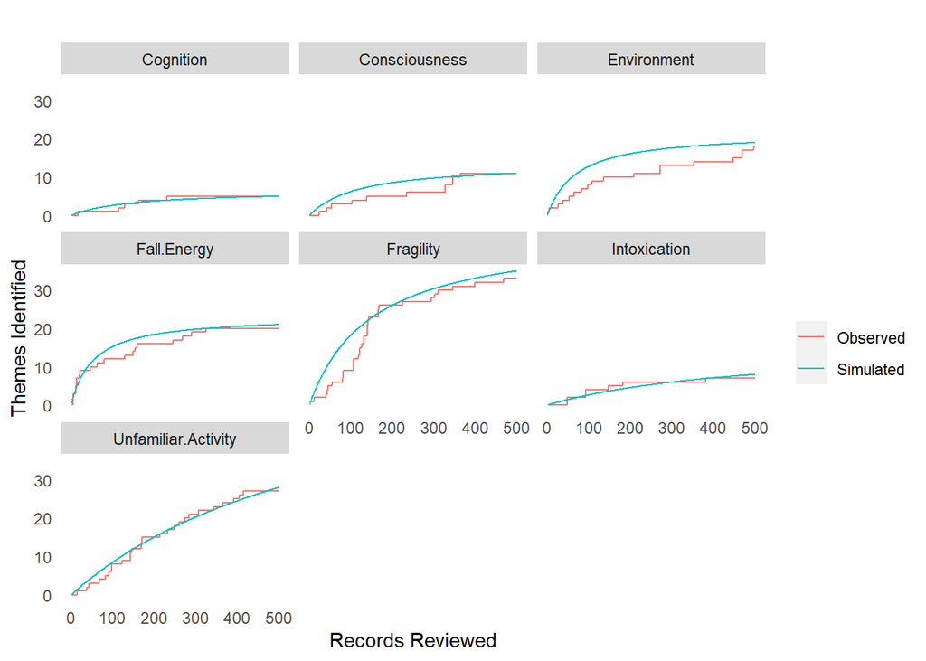

```r
    ests%>%

  ggplot(
         )+
    geom_line(aes(x=V1,y=cumsum,group=Label, color=Label))+
    theme(axis.ticks = element_blank(),
      panel.grid.minor = element_blank(),
      panel.grid.major = element_blank(),
      panel.background = element_blank(),
      plot.title = element_text(hjust = 0.5))+
      labs(y = "Themes Identified", x = "Records Reviewed", colour = "", title = "") +
    facet_wrap(~Topic)
```

We applied the qualitative coding to the remaining 114,628 observations using text embeddings and random forest imputation.

```r
 #Part 2A: Creating Training Data for Imputation Model (500 first narratives which were coded)
    #Function to Create Indicators for The Presence of Each Theme)
      lps<-function(ind){
            kwlist<-unique(kw[ind])
            kwlist<-kwlist[(kwlist=='')==FALSE]
            for  (i in 1:length(kwlist)) {
              df[,i]<-str_detect(my_data500$narrative, kwlist[i])
            }
            col<-apply(df, 1, max, na.rm=TRUE)
            return(col)
          }
    vars<-as.data.frame(lapply(c(1:7),lps))
    colnames(vars)<-topics
    vars$cpsc_case_number<-my_data500$cpsc_case_number

    #Retreiving Text Embeddings
      embed<-read_parquet("Data/openai_embeddings_primary_narratives.parquet.gzip")
      embed2<-as.data.frame(t(as.data.frame(lapply(as.matrix(embed[,2]),unlist))))
      embed3<-cbind(embed[,1],embed2[,1:100])

  #Part 2B Merging Training Data with Text Embeddings and finalizing formatting
    embed4<-vars%>%left_join(embed3)%>%
    mutate(Fall.Energy=as.factor(Fall.Energy),
       Intoxication=as.factor(Intoxication),
       Fragility=as.factor(Fragility),
       Unfamiliar.Activity=as.factor(Unfamiliar.Activity),
       Cognition=as.factor(Cognition),
       Environment=as.factor(Environment),
       Consciousness=as.factor(Consciousness))

  #Part 2C: Multiple Imputation to Predict Themes in Narratives that Weren't Coded
    embed5<-missForest(embed4)$ximp
```

```r
#Part4; Negative Binomial Regression To Identify Strongest Risk Factors
  #Adding Outcome Indicator to
    Outcome<-my_data%>%mutate(Outcome=ifelse(disposition>3,1,0))%>%dplyr::select(cpsc_case_number, Outcome, age, sex)
    embed6<-embed5%>%left_join(Outcome)
  #Negative Binomial Model
    nbm_coeff <- exp(glm(Outcome~Fall.Energy+Intoxication+Fragility+Unfamiliar.Activity+Cognition+Environment+Consciousness+age+sex,embed6,
      family='binomial')$coefficients) %>%
      as.list %>%
      as.tibble() %>%
      t() %>%
      data.frame()

    nbm_coeff$Theme <-  row.names(nbm_coeff)

    nbm_coeff %>%
      `colnames<-`(c("Risk Ratio","Theme")) %>%
      dplyr::select(Theme,`Risk Ratio`) %>%
      arrange(desc(`Risk Ratio`)) %>%
      transmute(Domain = str_replace(Theme,"1",""),
             `Risk Ratio` = round(`Risk Ratio`,2)) %>%
      filter(!(Domain %in% (c("age","sex","(Intercept)")))) %>%
      DT::datatable(rownames=NULL,
                    options = list(lengthChange = FALSE,
                                   searching = FALSE,
                                   info = FALSE))
```

| Domain | Risk Ratio |
| --- | --- |
| Consciousness | 2.55 |
| Intoxication | 1.98 |
| Fragility | 1.2 |
| Cognition | 1.09 |
| Fall.Energy | 1.05 |
| Unfamiliar.Activity | 0.81 |
| Environment | 0.59 |

## Conclusion

Our results suggest that the domains of intoxication, loss of consciousness, and patient fragility are the largest contributors to risk of severe fall in our data set. This agrees well with the judgement of our expert panel, which ranked all of these domains in the top half of factors related to more severe falls. Further confirming the jusgement of our clinician panel, unfamiliar environments and activities were not predicted to be top contributors to severe fall risk, and were not found to be associated with severe falls in our data set.

Our analysis has several important implications. The CDC’s STEADI Older Adult Fall Prevention plan identifies vetibular disorders/poor balance, vitamin D deficiency, medications linked to falls, postural hypotension, vision impairment, foot or ankle disorders, and home hazards as key modifiable risk factors for falls. While there is significant concordance between our findings and the CDC recommendations, intoxication is a key outlier. We found that intoxication nearly doubled the risk of a fall resulting in a serious outcome, but it was excluded from the CDC plan. This suggests that patients may not be routinely receiving interventions focused on the role of intoxicants in severe falls in guidance-driven fall prevention programs.

Second, the finding that unfamiliar environments and activities were not associated with falls suggests that restricting the activities of elderly individuals to reduce injury risk may be misguided in some circumstances. Indeed, appropriate physical and social activities may slow physical and cognitive decline, both supporting independence and potentially reducing the risk of serious falls.

Our analysis was subject to at least 3 limitations. First, falls entered into the NEISS database only included falls which resulted in an ED visit. It may be that patients are more likely to present to the ED for falls in certain contexts; for example, a nursing home might have a policy that all falls are evaluated in the ED. This would result in patients living in a nursing home (coded as more likely to be frail) having less severe falls; it therefore may be that the link between fragility and fall severity is stronger than we observed. Second, we limited our analysis to the data in the fall narrative, which excluded other information which may be associated with fall severity and may have resulted in undetected confounding factors. These could include relevant contextual information or information about underlying medical conditions. Finally, our data only focused on short term outcomes of falls, basded on disposition after the ED visit. We were not able to analyze the effects of falls on long-term quality of life, including whether patients required a hire level of long term care or new assistance with ADLs.

In sum, our analysis suggests that intoxication, loss of consciousness, and frailty are key factors resulting in more severe falls among elderly patients, while unfamiliar activities or environments are not associated with increased risk. Providers seeking to reduce the risk of serious falls among the elderly should consider counseling about intoxicants and should support engagement with age-appropriate activities.

## Abridged References

#### Literature

Bhattacharya, B., Maung, A., Schuster, K., & Davis, K. A. (2016). The older they are the harder they fall: injury patterns and outcomes by age after ground level falls. Injury, 47(9), 1955-1959.

Fick, D. M., Cooper, J. W., Wade, W. E., Waller, J. L., Maclean, J. R., & Beers, M. H. (2003). Updating the Beers criteria for potentially inappropriate medication use in older adults: results of a US consensus panel of experts. Archives of internal medicine, 163(22), 2716-2724.

Guest, G., Namey, E., & Chen, M. (2020). A simple method to assess and report thematic saturation in qualitative research. PloS one, 15(5), e0232076

Joseph, B., Pandit, V., Khalil, M., Kulvatunyou, N., Zangbar, B., Friese, R. S., … & Rhee, P. (2015). Managing older adults with ground‐level falls admitted to a trauma service: the effect of frailty. Journal of the American Geriatrics Society, 63(4), 745-749.

Tinetti, M. E., Speechley, M., & Ginter, S. F. (1988). Risk factors for falls among elderly persons living in the community. New England journal of medicine, 319(26), 1701-1707.

#### Statistical Packages

Arnold J (2021). _ggthemes: Extra Themes, Scales and Geoms for ‘ggplot2’_. R package version 4.2.4, https://CRAN.R-project.org/package=ggthemes.

Auguie B (2017). _gridExtra: Miscellaneous Functions for “Grid” Graphics_. R package version 2.3, https://CRAN.R-project.org/package=gridExtra.

Daniel J. Stekhoven (2022). missForest: Nonparametric Missing Value Imputation using Random Forest. R package version 1.5.

Garrett Grolemund, Hadley Wickham (2011). Dates and Times Made Easy with lubridate. Journal of Statistical Software, 40(3), 1-25. URL https://www.jstatsoft.org/v40/i03/.

Haine, Denis (2023). The episensr package: basic sensitivity analysis of epidemiological results. R package version 1.3.0. https://dhaine.github.io/episensr/. doi: 10.5281/zenodo.8299430.

R Core Team (2023). _R: A Language and Environment for Statistical Computing_. R Foundation for Statistical Computing, Vienna, Austria. https://www.R-project.org/.

Richardson N, Cook I, Crane N, Dunnington D, François R, Keane J, Moldovan-Grünfeld D, Ooms J, Apache Arrow (2023). _arrow: Integration to ‘Apache’ ‘Arrow’_. R package version 13.0.0.1, https://CRAN.R-project.org/package=arrow.

Stevens, J. A. (2013). The STEADI tool kit: a fall prevention resource for health care providers. The IHS primary care provider, 39(9), 162.

Venables, W. N. & Ripley, B. D. (2002) Modern Applied Statistics with S. Fourth Edition. Springer, New York. ISBN 0-387-95457-0

Wickham H, Averick M, Bryan J, Chang W, McGowan LD, François R, Grolemund G, Hayes A, Henry L, Hester J, Kuhn M, Pedersen TL, Miller E, Bache SM, Müller K, Ooms J, Robinson D, Seidel DP, Spinu V, Takahashi K, Vaughan D, Wilke C, Woo K, Yutani H (2019). “Welcome to the tidyverse.” _Journal of Open Source Software_, *4*(43), 1686. doi:10.21105/joss.01686 https://doi.org/10.21105/joss.01686.